# Chapter 3: Statistics Review (Problems)

## Review the Concepts

#### 3.1) Explain the difference between the sample average $\overline{Y}$ and the population mean.

A: The sample average $\overline{Y}$ is the mean of a sample, i.e. a subset of the population. The population mean is the mean of the entire population.

#### 3.2) Explain the difference between an estimator and an estimate. Provide an example of each.

A: An estimator is a random variable, whose value depends on a given sample. An estimate is an actual value the estimator takes at a given sample. So for example, the sample average $\overline{Y}$ is an estimator, whose value will change as we draw different samples. For a given sample, we might have $\overline{Y}=100$ and that 100 is an estimate for the population mean.

#### 3.3) A population distribution has a mean of 10 and variance of 16. Determine the mean and variance of $\overline{Y}$ from an i.i.d. sample from this population for: (a) $n=10$ ; (b) $n=100$ ; (c) $ n=1000$. Relate your answer to the law of large numbers.

A: Since $\overline{Y}$ is an unbiased estimator for the population mean, we will always have $E(\overline{Y}) = 10$ no matter the same size $n$. For the variance, we have

$$Var(\overline{Y}) = \frac{Var(Y)}{n}$$

1. $Var(\overline{Y})=16/10 = 1.6$
2. $Var(\overline{Y})=16/100 = 0.16$
3. $Var(\overline{Y}) = 16/1000 = 0.016$

Notice that as $n\to \infty$, we have $Var(\overline{Y}) \to 0$, which says that the variability of the sample mean $\overline{Y}$ vanishes as the sample size gets larger. In other words, the sample mean $\overline{Y}$ converges in probability to the population, which is just the law of large numbers.

#### 3.4) What role does the Central Limit Theorem play in statistical hypothesis testing? In the construction of confidence intervales?

A: In order to conduct hypothesis tests or construct confidence intervals, we must be able to compute the CDF of the estimator in question. An estimator, by definition, is just a random variable and their behavior can be very "wild". However, in the case of the sample mean $\overline{Y}$, the Central Limit Theorem allows us to approximate $\overline{Y}$ as approximately normal, which allows to us to make computations using the CDF. This in turn allows us to compute p-values and construct confidence intervals.

#### 3.5) What is the difference between a null hypothesis and an alternative hypothesis? Among size, significance level, and power? Between a one-sided alternative hypothesis and a two-sided alternative hypothesis?

A: A null hypothesis is the default hypothesis which pre-supposes a parameter value (e.g. $\mu = 5$). The alternative hypothesis is a hypothesis which holds, when the null hypothesis fails. Alternative hypothesis come in 2 flavors: 2-sided alternative (e.g. $\mu \neq 5$) and 1-sided alternative (e.g. $\mu > 5$).

The **size** of a test is probability of making a Type II error: we reject the null hypothesis when it is true (i.e. the false positive rate). The **power** of the test is how likely we are to reject the null hypothesis when it is in-fact false (i.e. the true positive rate). The **significance level** $\alpha$ is the threshold with which we compare the p-value against and is used to decide where to accept or reject the null hypothesis. A higher $\alpha$ will mean rejection is more easily triggered, so we will reject the null hypothesis more often. Hence a higher $\alpha$ increases both size and power of the test. Conversely, a lower $\alpha$ means rejection is harder, so we will fail to reject the null hypothesis more often. Hence a lower $\alpha$ decreases both size and power of the test.

#### 3.6) Why does a confidence interval contain more information than the results of a single hypothesis test?

A: By definition, a confidence interval is the set of values $\mu_0$ for which the null hypothesis $\mu =\mu_0$ will fail to be rejected for a given sample at a given significance level. For example, suppose we have a sample with mean $\overline{Y}=10$. A **95% confidence interval** is the set of all values $\mu_0$ such that the following condition is true:

"If the null hypothesis is $\mu=\mu_0$, then we will fail to reject the null hypothesis $\mu=\mu_0$ at a 100%-95% = 5% = $\alpha$ significance level."

Heuristically, the 95% confidence interval is the set of all possible null hypothesis values $\mu_0$ that would not register as postive on a hypothesis test at 5% significance level. For this reason, a confidence interval can be thought of as containing the results of infinitely many hypothesis tests (one test for each value in the interval).

#### 3.7) Explain why the difference-of-means estimator, applied to data from a randomized experiment, is an estimator for the treatment effect.

A: Let us quickly remind ourselves of the estimators in question. The **casaul effect** or **treatment effect** is the parameter $$E(Y|X=1) - E(Y|X=0)$$

In other words, the treatment effect is the difference in expected values of $Y$ between the treatment group $X=1$ and the control group $X=0$.

Let $Y_0$ denote the random variable corresponding to the conditional distribution $Pr(Y|X=0)$.  
Let $Y_1$ denote the random variable corresponding to the conditional distribution $Pr(Y|X=1)$.

Then the sample means $\overline{Y_0}$ and $\overline{Y_1}$ are unbiased estimators for $Y_0$ and $Y_1$ respectively. Therefore: $$E(\overline{Y_0}) = E(Y_0)$$ $$E(\overline{Y_1}) = E(Y_1)$$

And therefore: $$E(\overline{Y_1} - \overline{Y_0}) = E(\overline{Y_1})-E(\overline{Y_0})=E(Y_1)-E(Y_0) = E(Y|X=1) - E(Y|X=0)$$

Therefore the statistic $\overline{Y_1}-\overline{Y_0}$ is an unbiased estimator for the treatment effect $E(Y|X=1)-E(Y|X=0)$.

#### 3.8) Sketch a hypothetical scatterplot for a sample size of 10 for two random variables with population correlation of (a) 1.0 ; (b) -1.0 ; (c) 0.9 ; (d) -0.5 ; (e) 0.0.

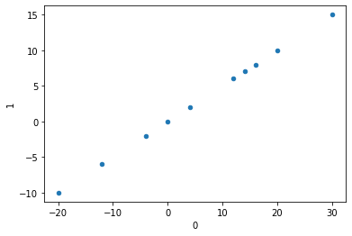

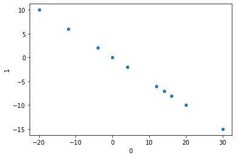

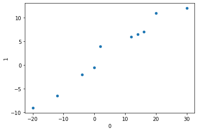

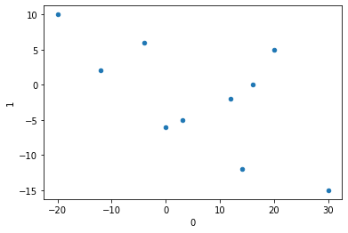

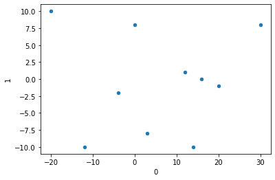

## Exercises

#### 3.1) In a population $\mu_Y=100$ and $\sigma^2_Y=43$. Use the CLT to answer the following questions:

1. In a sample of $n=100$, find $Pr(\overline{Y} <101)$.
2. In a sample of $n=64$, find $Pr(101 < \overline{Y} <103)$.
3. In a sample of $n=165$, find $Pr(\overline{Y}>98)$.

A: By the CLT, the sample mean $\overline{Y}$ is approximately normal with $$\overline{Y} \sim N\left(100, \frac{43}{\sqrt{n}}\right)$$

```
0.9363686681897804
```

```
0.11110848082068059
```

```
0.9999553120411752
```

#### 3.2) Let $Y$ be a Bernoulli random variable with success probability $Pr(Y=1) = p$ and let $Y_1,\ldots,Y_n$ be i.i.d. draws from this distribution. Let $\hat{p}$ be the fraction of the successes (1's) in this sample.

1. Show that $\hat{p} = \overline{Y}$.
2. Show that $\hat{p}$ is an unbiased estimator of $p$.
3. Show that $Var(\hat{p}) = p(1-p)/n$.

A:

1) By definition, the estimator $\overline{Y}$ is the mean of the $Y_i$ and hence we have: $\overline{Y} = \frac{1}{n}\sum_{i=1}^n Y_i$. But notice that the value of $Y_i$ is either 1 or 0 and so the sum $\sum_{i=1}^n Y_i$ gives the total number of success. Therefore $$\overline{Y} = \frac{1}{n}\sum_{i=1}^n Y_i = \frac{1}{n}\cdot (\text{ # of successess } ) = \hat{p}$$

2) By the definition of a Bernoulli random variable, we have $E(Y) = p$ and by the previous part $$E(\hat{p}) = E(\overline{Y}) = E(Y) = p$$

3) By the first part, we have $\hat{p}=\overline{Y}$. Also, since the $Y_i$ are i.i.d. the variance of the sum $\sum_{i=1}^n Y_i$ is additive and therefore: $$ \begin{align*} Var(\hat{p}) &= Var(\overline{Y}) \\ &= Var\left(\frac{1}{n}\sum_{i=1}^nY_i\right) \\ &=\frac{1}{n^2}\sum_{i=1}^nVar(Y_i) \\ &= \frac{1}{n^2}\sum_{i=1}^n Var(Y) \\ & = \frac{1}{n^2}\cdot n\cdot Var(Y) \\ & = \frac{1}{n}\cdot Var(Y)\\ & = \frac{1}{n} \cdot p(1-p) \end{align*}$$

where we used the fact that the variance of a Bernoulli random variable $Y$ is precisely $p(1-p)$.

#### 3.3) In a survey of 400 likely voters, 215 responded that they would vote for the incumbent, and 185 responded that they would vote for the challenger. Let $p$ denote the fraction of all likely voters who preferred the incumbent at the time of the survey, and let $\hat{p}$ be the fraction of the survey respondents who preferred the incumbent.

1. Use the survey results to estimate $p$.
2. Use the estimator of the variance of $\hat{p}$,
3. What is the $p$-value for the test $H_0: p=0.5$ vs $H_1:p\neq = 0.5$?
4. What is the $p$-value for the test $H_0: p=0.5$ vs $H_1:p>0.5$?
5. Why do the results from (3) and (4) differ?
6. Did the survey contain statistically significant evidence that the incumbent was ahead of the challenger at the time of the survey? Explain

A:

1 ) Using the sample proportion $\hat{p}$ as an estimator for $p$, we have $p \approx \hat{p} = \frac{215}{400} = 0.5375$

```
0.5375
```

2 ) Using $\hat{p}(1-\hat{p})/n$ as an estimator for $Var(\hat{p})=p(1-p)/n$, we have: $$SE(\hat{p}) = \sqrt{Var(\hat{p})} \approx \sqrt{\frac{\hat{p}(1-\hat{p})}{n}} = 0.0249295883439... $$

```
0.02492958834397391
```

3 ) By definition, the $p$-value of the sample statistic $215/400 = 0.5375$ is the probability of observing a result at least as extreme as our given sample. The phrase "at least as extreme" can have 2 meanings. "2-tailed" which means as extreme in either direction away from the mean. "1-tailed" which means as extreme in one specified direction away from the mean.

We have $\hat{p}=215/400 = 0.5375$. The (2-tailed) $p$-value for this sample estimate is the probability that $\hat{p}$ is at least as far away from the hypothesized mean $p=0.5$ as the observe sample statistic $0.5375$. $$P(\hat{p} > 0.5375) + P(\hat{p} < 0.4625) $$

Let $Y$ be the random variable associated with randomly selecting a likely voter. Then $Y$ is a Bernoulli random variable with $Y=1$ meaning the selected voter supports the incumbent and $Y=0$ meaning otherwise. Let $Y_1,\ldots, Y_{400}$ be 400 i.i.d. draws of this Bernoulli random variable. By question 3.2 we have $$\hat{p} = \overline{Y}$$ In particular $\hat{p}$ is a sample mean, hence the Central Limit Theorem can be applied, and we can say $\hat{p}$ is approximately normally distributed: $$\hat{p}\sim N\left(p \,\,, \sqrt{\frac{p(1-p)}{n}}\right)$$

Since we are hypothesizing that the true value of $p$ is $p=0.5$, we thus have: $$\hat{p}\sim N(0.5, 0.025) $$

We can thus compute the desired probabilities $P(\hat{p} > 0.5375) + P(\hat{p}<0.4625)$

```
(0.0668072012688582, 0.06680720126885817, 0.13361440253771636)
```

So the $p$-value for this test is $0.1336$

4 ) Again, the $p$-value of the sample statistic $215/400 = 0.5375$ is the probability of observing a result at least as extreme as our given sample. For 1-tailed hypothesis, "at least as extreme" means **at least as large** as our sample statistic of $0.5375$.

$$P(\hat{p}>0.5375)$$

As computed above, this probability is $0.0668$.

5 ) The reason for the discrepancy comes down to the difference in the alternative hypotheses. The first hypothesis simply wishes to demonstrate that $p\neq 0.5$ and so sample statistics in both directions $\hat{p}<0.5$ and $\hat{p}>0.5$ would both be evidence for $p\neq 0.5$. Thus the phrase "at least as extreme" means any statistic as far away in both directions.

The second hypothesis wishes to demonstrate $p > 0.5$, so only sample statistics in the direction of $\hat{p}>0.5$ will provide evidence for this hypothesis. Thus the phrase "at least as extreme" means statistics which are as large as the sample value of $0.5375$.

More heuristically, we are using the sample statistic value $\hat{p}=p_0$ as evidence for the alternative hypothesis. It is MUCH easier to get samples with $\hat{p} \neq 0.5$ than it is to get samples with $\hat{p} > 0.5$. In fact the computations above show us that it is exactly TWICE as likely to get samples with $\hat{p} \neq 0.5$ than to get samples with $\hat{p} > 0.5$.

6 ) If we wanted to conduct a proper hypothesis test, the proper thing to do would be to declare a significance level at the beginning. If we default to the standard significance level of $\alpha = 0.05$, then the answer is:

```
"NO! the survey did not contain statistically significant evidence that the incumbent was ahead of the challenger."
```

#### 3.4) Using the data in Exercise 3.3:

1. Construct a 95% confidence interval for $p$
2. Construct a 99% confidence interval for $p$
3. Why is the interval in (2) wider than the interval in (1)
4. Without doing any additional calculations, test the hypothesis $H_0: p=0.5$ vs $H_1:p\neq 0.5$ at the 5% significance level.

A:

1 ) By definition, the 95% confidence interval is an interval of the form: $$CI(\hat{p}) = (\hat{p}-a, \hat{p}+a)$$ Such that $Pr( p \in CI(\hat{p})) = 0.95$. More precisely, let $Y$ be Bernoulli random variable such $Y=1$ if $p\in CI(\hat{p})$ and $Y=0$ otherwise. Since $\hat{p}$ is a random variable, $CI(\hat{p})$ is also random and will output different intervals depending on a given random sample. Thus $Y$ is a random variable and we consider the **capture/coverage probability** $$Pr(Y=1)$$

We say $CI(\hat{p})$ is a **95% confidence interval** if $Pr(Y=1)=0.95$.

Notice that random variable $CI(\hat{p})=(\hat{p}-a, \hat{p}+a)$ is parameterized by the constant $a$. Thus to actually find the 95% confidence interval, it suffices to find the value $a$ for which $Pr(p\in CI(\hat{p}) ) = 0.95$.

$$\begin{align*} Pr(p\in CI(\hat{p})) &= Pr(\hat{p}-a < p < \hat{p}+a)\\ & = Pr(-a < p-\hat{p} < a) \\ & = Pr(a > \hat{p}-p > -a) \\ & = Pr(-a < \hat{p} - p < a) \\ \end{align*}$$

Thus we are looking for the value $a$ for which $$Pr(-a < \hat{p} - p < a) = 0.95$$

Note that $p$ is just a constant, so the quantity $\hat{p}-p$ is a random variable whose distribution is just a shifted copy of $\hat{p}$. Generally, we need to know the distribution of $\hat{p}$ to proceed with the computation of $a$. In our case, the CLT guarantees that $\hat{p}$ is approximately normally distributed: $$\hat{p} \sim N(p, SE(\hat{p})$$ $$\hat{p}-p \sim N(0, SE(\hat{p}))$$ Thus $a$ can be solved for via the inverse CDF of the normal distribution:

```
(-0.048861095303598404, 0.0488610953035984)
```

Thus the desired $a$ value is $0.04886$ and the 95% Confidence Interval is given by: $$CI = (0.5375 - 0.04886, 0.5375 + 0.04886) = (0.4886, 0.5863)$$

```
(0.4886389046964016, 0.5863610953035984)
```

2 ) We can similarly construct a 99% confidence interval via the same logic: $$Pr(-a < \hat{p}-p < a) = 0.99$$

with $\hat{p}-p \sim N(0, SE(\hat{p}))$. Using the inverse CDF of the normal distribution:

```
(-0.06421436418181911, 0.0642143641818191)
```

Thus the desired quantity $a$ is $0.0642$ and the 99% confidence interval is: $$CI = (0.5375 - 0.0642, 0.5375+0.0642) = (0.4733, 0.6017)$$

```
(0.47328563581818084, 0.6017143641818191)
```

3 ) Notice that the 99% confidence interval is wider than the 95% confidence interval. This makes sense intuitively: in order for us to increase the capture probability, we have to increase the size of the interval (i.e. cast a "wider net"). This highlights a fundamental trade-off between **accuracy** (how pinpoint we can make the interval) versus the **confidence** (how likely we are to capture the correct value).

4 ) There is an equivalent interpretation of the 95% confidence interval, which relates the CI to hypothesis testing. Specifically, the **$(1-\alpha)100\%$ confidence interval** consists of all the values $p_0$ which would pass a hypothesis test at **significance level $\alpha$** given the sample we have.

Why is this is the case? Let $\hat{p}_0$ denote the sample value of $\hat{p}$ and let $$CI(\hat{p}_0) = (\hat{p}_0 - a, \hat{p}_0+a)$$ be the $(1-\alpha)100\%$ confidence interval computed for the given sample. Let $p_0 \in CI(\hat{p}_0)$ and consider the hypothesis: $$H_0: p=p_0$$ $$H_1: p\neq p_0$$ Let us proceed to carry out the hypothesis test by assuming $H_0$ is true. Then $p=p_0$. Without loss of generality, suppose $\hat{p}_0 > p_0$ and so $\hat{p}_0 - p_0 > 0 $ (the negative case is similar).

By definition, the $p$-value is the probability of observing a value of $\hat{p}$ "as extreme" or "as far away from the expected value" as our given sample $\hat{p}_0$:

$$\begin{align*} \text{p-value} &= Pr(\hat{p} -p_0 > \hat{p}_0 -p_0) + Pr(\hat{p}-p_0<-(\hat{p}_0-p_0)) \\ & = 1 - Pr(-(\hat{p}_0-p_0) < \hat{p} - p_0 < \hat{p}_0 - p_0 )\\ \end{align*}$$

Since $p_0 \in (\hat{p}_0-a, \hat{p}_0+a)$, we have: $$\begin{align*} \hat{p}_0-a < p_0 < \hat{p}_0 + a \\ -a < \hat{p}_0 - p_0 < a \\ a > -(\hat{p}_0 -p_0) > -a \\ \end{align*}$$

In particular, we have $\hat{p}_0 - p_0 < a$ and $-a<-(\hat{p}_0 - p_0)$. Therefore: $$( -(\hat{p}_0-p_0) , \hat{p}_0 - p_0) \subseteq (-a, a)$$ $$Pr(-(\hat{p}_0-p_0) < \hat{p}-p_0 < \hat{p}_0-p_0) ) < Pr( -a < \hat{p}-p_0 < a) = Pr(\hat{p}-a < p_0 < \hat{p}+a) = (1-\alpha)$$

As we are assuming $p=p_0$ and by definition of the $(\hat{p}-a, \hat{p}+a)$ is the $(1-\alpha)100\%$ confidence interval (and hence the final equality is the same as the capture probability). Therefore: $$ \text{p-value} = 1 - Pr(-(\hat{p}_0-p_0) < \hat{p}-p_0 < \hat{p}_0-p_0) ) > 1 - (1-\alpha) = \alpha$$

In other words, the $p$-value of the sample is **greater** than the significance level $\alpha$, hence we will fail to reject the null hypothesis $H_0: p=p_0$.

Since the choice of $p_0\in CI(\hat{p}_0)$ was arbitrary, the result holds for all $p_0\in CI(\hat{p}_0)$. Therefore:

#### For every $p_0\in CI(\hat{p_0})$, we will fail to reject the null hypothesis $H_0: p=p_0$ at a significance level of $\alpha$, given our sample statistic $\hat{p}_0$. That is, the $(1-\alpha)100\%$ confidence interval contains all the values that would pass a hypothesis test at significance level $\alpha$ of our given sample.

In particular, the 95% confidence interval $CI(\hat{p}_0) = (0.4886,0.5863)$ holds all the hypothesized values $p=p_0$ for which a hypothesis test would fail to reject the null hypothesis $H_0: p=p_0$. Since $p=0.5$ is a value within the interval, we automatically know that a hypothesis test will fail to reject the null hypothesis.

#### 3.7) In a given population, 11% of the likely voters are African American. A survey using a simple random sample of 600 landline telephone numbers finds 8% African American. Is there evidence that the survey is biased? Explain.

A: We shall conduct a statistical test and specify a signficance level of $\alpha=0.05$. Let $\hat{p}$ denote the percentage of people who identify as African American in a survey of 600 people. Then $\hat{p}$ is approximately nomral with $$\hat{p} \sim N(p, SE(\hat{p})) = N\left(0.11, \sqrt{\frac{0.11*(0.89)}{600}}\right)$$ $$\hat{p} \sim N(0.11, 0.01277)$$

```
Standard Error:  0.012773670837573147
```

```
0.018845102309145115
```

So there is approximately a 1.9% chance of observing a result as extreme as our sample. This is low enough for use to consider something amiss, so we believe there is evidence of bias in the survey method.

#### 3.8) A new version of the SAT is given to 1000 randomly selected high school seniors. The sample mean test score is 1110, and the sample standard deviation is 123. Construct a 95% confidence interval for the population mean test score for high school seniors.

A: Let $\overline{Y}$ be the mean test score of a random sample of 1000 high school seniors. By the Central Limit Theorem, $\overline{Y}$ is approximately normal with $$\overline{Y} \sim N(\mu, SE(\overline{Y})) = N\left(\mu, \frac{\sigma}{\sqrt{1000}}\right)$$ $$\overline{Y}-\mu \sim N\left(0, \frac{\sigma}{\sqrt{1000}}\right)$$

where $\sigma$ is the population Standard Deviation. Unfortunately, we do not know $\sigma$, so we cannot use this distribution of $\overline{Y}$ directly.

Instead, what we can do is engineer a new random variable called the **t-statistic**

$$t := \frac{\overline{Y}-\mu}{\left(\frac{\overline{\sigma}}{\sqrt{1000}}\right)}$$

Where $\overline{\sigma}$ is the standard deviation of the sample. Then $\overline{\sigma}$ is a random variable (whose value changes depending on the random sample) and $\overline{\sigma}$ is an unbiased estimator for the population standard deviation $\sigma$. Furthermore $\overline{\sigma}$ will follow a Chi-squared distribution with $\nu = 1000-1 = 999$ degrees of freedom. The key insight here is that we **actually know** the value of $\overline{\sigma}$ from the sample, which means we can also explicitly make computations from the distribution of the $t$-statistic.

By construction then, $t$ is the quotient of a normal random variable $\overline{Y}-\mu$ by a Chi-squared random variable $\frac{\sigma}{\sqrt{1000}}$ and hence $t$ will follow Student's $t$-distribution.

We want to construct a $95\%$ confidence interval, hence we need to find values $a$ for which the random interval $CI(\overline{Y}) = (\overline{Y}-a, \overline{Y}+a)$ has a capture probability of 95%: $$Pr(\mu\in CI(\overline{Y}))= 0.95$$ $$Pr(-a < \overline{Y}-\mu < a ) = 0.95$$ $$Pr\left(-\frac{a}{\overline{\sigma}/\sqrt{1000}} < \frac{\overline{Y}-\mu}{\overline{\sigma}/\sqrt{1000}} < \frac{a}{\overline{\sigma}/\sqrt{1000}}\right) = 0.95$$ $$Pr\left(-\frac{a}{\overline{\sigma}/\sqrt{1000}} < t < \frac{a}{\overline{\sigma}/\sqrt{1000}}\right) = 0.95 $$

Thus, we can use the inverse CDF of the $t$-distribution with 999 degrees of freedom.

```
(-1.962341461133449, 1.9623414611334487)
```

And thus: $$\frac{a}{\overline{\sigma}/\sqrt{1000}} = 1.9623 $$ $$ a = 1.9623\cdot\frac{\overline{\sigma}}{\sqrt{1000}}$$

This yields the desired 95% confidence interval as: $$CI(\overline{Y}) = (\overline{Y}-a, \overline{Y}+a) = (1110-7.632, 1110+7.632) = (1102.37, 1117.632)$$

```
7.6325650666345455
```

```
(1102.3674349333655, 1117.6325650666345)
```